# SOE Simulations Manuscript

Sean Hardison, Charles Perretti, Andy Beet, Geret DePiper

June 29, 2018

## Introduction

The development and analysis of indicators plays a key strategic role in implementing the Ecosystem Approach for a host of science, management, and intergovernmental organizations (e.g. NOAA 2006; ICES 2013; Secretariat of the Convention on Biological Diversity 2004; Perry, Livingston, and Fulton 2010; Garcia et al. 2003; Levin et al. 2009). At least partially in support of this, substantial effort has been invested in assessing indicator status and trends for the purpose of ecosystem reporting, in all of its guises (e.g. Garfield and Harvey 2016; NEFSC 2018a; NEFSC 2018b; Blanchard et al. 2010; O’Brien 2017; Butchart et al. 2010).

Ecosystem-level indicators often vary greatly with respect to the length of the series under investigation. The ultimate goal of providing integrated advice often leads analysts to truncate longer datasets; generating a consistent series length across indicators for comparison purposes (e.g. Blanchard et al. 2010; Shin and Shannon 2010; Shannon et al. 2010; Canales et al. 2015). Further reinforcing this approach is the fact that managers tend to focus on short-term issues (Secretariat of the Convention on Biological Diversity 2004; Wagner et al. 2013), which ultimately necessitates the assessment of trajectories at relatively short time scales.

These issues can lead to the use of short time series for the purpose of ecosystem reporting; i.e. less than 20 data points per indicator (Blanchard et al. 2010; Shin and Shannon 2010; Shannon et al. 2010; Canales et al. 2015; Mackas, Thomson, and Galbraith 2001; Nicholson and Jennings 2004). Statistical trend analysis of indicator data is the gold standard for managers, stakeholders, and analysts. However, in reality trend analysis in this context can be extremely difficult. Evidence indicates that the statistical power to identify trends using short time series may be limited in general (Nicholson and Jennings 2004; Wagner et al. 2013). The hydrological and climatological literature shows that autocorrelation in time series can falsely inflate trend detection rates when models are incorrectly specified assuming the independence of error terms (Kulkarni and Storch 1995; Storch 1999; Zhang et al. 2000; Wang and Swail 2001; Yue and Wang 2002; Bayazit 2015).The magnitude of assigned trends can also be inflated by the presence of autocorrelation, and both of these problems are amplified by short time series (Kulkarni and Storch 1995; Yue and Wang 2002). Despite this, there has been no systematic investigation for the performance of models in detecting trends across the full breadth of indicators utilized in ecosystem reporting.

In this manuscript we abstract away from issues surrounding the identification and vetting of appropriate indicators, but note that this in itself can be a challenging undertaking for which Bundy, Gomez, and Cook (2017) present a survey of the literature. We focus, instead, on the ability to statistically identify trends for the broad array of indicators used in marine ecosystem reporting; ranging from large-scale climatological and oceanographic drivers through the benefits derived by human society. We use Monte Carlo simulations to assess the performance of the most commonly applied statistical models under a range of time series lengths, trend strengths, and autocorrelation regimes. The simulations are parameterized using the properties of indicators currently presented in the Mid-Atlantic and New England State of the Ecosystem Reports, which are annual ecosystem status reports tailored for the U.S. Mid-Atlantic and New England Fishery Management Councils respectively (NEFSC 2018a; NEFSC 2018b).

Results indicate that correctly identifying trends is problematic using less than 30 data points, with both Type I and Type II error common. Even under the strongest signal-noise ratio (i.e. strong trends and no autocorrelation) tests perform poorly with only ten data points. The simulations highlight problems associated with standardizing approaches across indicators, and suggest that further thought is warranted on status and trend analysis in the context of ecosystem reporting.

## Methods

#### Simulations

Simulated time series were generated through the addition of $AR(1)$ autoregressive processes to first-order linear models:

$$y = X\beta + \varepsilon_{t}, \:\: \mathrm{where} \:\: \varepsilon_{t} = \phi\varepsilon_{t-1} + \nu_{t}$$

#### Generalized least squares

The Generalized Least Squares (GLS) model fitting process used here was an iterative model-selection approach. Two first order linear and two quadratic GLS models were fit to each simulated time series and best models were chosen using small sample AIC (AICc). One of each of the two linear and quadratic GLS models were specified with first-order autocorrelated error structure identical to the error process used to generate simulations.

$$b_{GLS} = (X'\Sigma^{-1} X)^{-1}X'\Sigma^{-1}y,$$

where $y$ is the response vector, and $X$ is an $n\:\times\:p$ model matrix. The covariance matrix of $b_{GLS}$ is

$$\mathrm{Var}(b_{GLS}) = (X'\Sigma^{-1}X)^{-1}.$$

The second pair of first order linear and quadratic GLS models were specified with normal error structure, $N(\mu,\sigma^{2})$. After selecting the best performing model using AICc, we performed likelihood ratio tests between the selected and null models specifying a maximum-likelihood approach to test the null of no trend given $\alpha = 0.05$.

#### Mann Kendall test

Further tests for trend in simulated time series were performed using the Mann-Kendall test (MK) (Mann 1945; Kendall 1975) and the more robust Mann-Kendall test with trend-free pre-whitening (MK-TFPW) (Yue et al. 2002). The MK test is a non-parametric test for trend that assumes sample data are independent and identically distributed; an assumption frequently violated in time series data. Serial correlation within sample data will lead to inflated rejection rates of the null hypothesis of no trend if no correction steps are applied to the MK test (von Storch 1995), such as residual pre-whitening, although pre-whitening is known to reduce the magnitude of existing trend (Yue et al. 2002). The Mann-Kendall with trend-free pre-whitening is a step-wise procedure developed by Yue et al. 2002 to address issues introduced by pre-whitening, and is further detailed below. Under both MK and MK-TFPW frameworks, Kendall’s tau statistic is given by:

$$S = \sum_{i=1}^{n-1}\sum_{j=i+1}^{n}\textrm{sgn}(y_{j} - y_{i}),$$
where $y$ is the response vector, $n$ is the length of the series, and

$$\textrm{sgn}(x)=\begin{Bmatrix}
1 & \textrm{if}\:x>0\\
0 & \textrm{if}\:x=0\\
-1 & \textrm{if}\:x<0
\end{Bmatrix}.$$

When there are no ties in the data, the variance of $S$ is given by

$$V(S) = \frac{n(n-1)(2n+5)}{18},$$
and the distribution of $S$ when $n \geq 8$ is approximately normal and symmetric about a mean of 0. We then perform a two-sided test for trend using the standardized $Z$ statistic:

$$\textrm{Z}=\begin{Bmatrix}
\frac{S-1}{\sqrt{V(S)}} & S>0\\
0 & S=0\\
\frac{S+1}{\sqrt{V(S)}} & S<0\\
\end{Bmatrix},$$

which is drawn from a normal distribution with mean of zero and variance of one. Following Yue et al. 2002, a $P$ value for the test is determined using the standard normal cumulative distribution function

$$P = \int_{\infty}^{Z}e^{-t^{2}/2}\mathrm{d}t.$$
For significance level $\alpha$, if $Z_{a/2} > |P|$, then we reject $H_{0}$ of no trend.

#### Mann-Kendall trend-free pre-whitening (MK-TFPW)

The Mann Kendall trend-free pre-whitening procedure as developed by Yue et al. 2002 is composed of four steps: 1. *Removal of trend* - The slope of trend $b$ is estimated using the Theil-Sen estimator (Theil 1950a-c; Sen 1968) and removed from sample data if different from zero, where $b$ is given by
$$b = \mathrm{Median}\left (\frac{X_{j} - X_{i}}{j - l}\right)\forall l < j .$$
Trend $b$ is removed from the series by
$$X_{t}^{'} = X_{t} - bt,$$
where $X_{t}$ is the original series at time step $t$. 2. *Trend-free pre-whitening* - A pre-whitening step is applied to the detrended series to remove the $AR(1)$ component. First, the lag-$1$ autocorrelation coefficient $\rho_{1}$ is computed using
$$\rho_{k} = \frac{ \frac{1}{n-k} \sum_{t=1}^{n-k}[X_{t} - E(X_{t})][X_{t+k} - E(X_{t})]} {\frac{1}{n}\sum_{t=1}^{n}[X_{t} - E(X_{t})]^2},$$
where $E(X_{t})$ is the mean of the series and $\rho_{k}$ is the lag-$k$ autocorrelation coefficient. Serial correlation is then removed from the detrended series $X_{t}^{'}$ by
$$Y_{t}^{'} = X_{t}^{'} - \rho_{1}X_{t}^{'}.$$
3. *Blending trend and residual series* - Trend $b$ is added to the independent residual series $Y_{t}^{'}$ by
$$Y_{t} = Y_{t}^{'} + bt.$$
4. *MK test* - Trend is assessed through the application of the Mann Kendall test as discussed above.

## Results

#### Assessing power of trend detection tests under varying levels of autocorrelation, trend strength, and time series lengths.

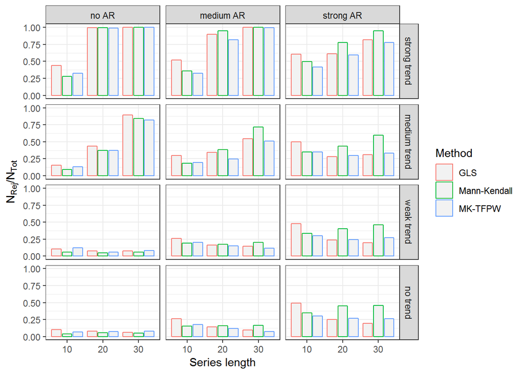

Barplots showing the ratio of number of rejections (<0.05) to number of total simulations. Subplots are representative of different autocorrelation and trend scenarios, with time series length increasing along the x axis. Colored bars show results from different tests for trend.

Autocorrelation is known the reduce the power of the MK test by increasing the variance of the statistic (Yue and Wang 2002). Identifying this problem led to the development of the MK-PW and other stepwise approaches that sought to address issues introduced by the MK-test when assumptions of independence are violated (Wang et al. 2000, Yue et al. 2002). Our work agrees with these authors and others (von Storch 1995) showing that under no simulated trend, introducing autocorrelation leads to inflated rejection rates in the MK test. Figure 1 shows that under no trend and strong autocorrelation ($\rho = 0.433$ and $\rho = 0.8$), the rejection rate of the Mann Kendall test increases with series length. All other tests showed decreases in rejection rates under both medium and strong autocorrelation scenarios with increasing series length.

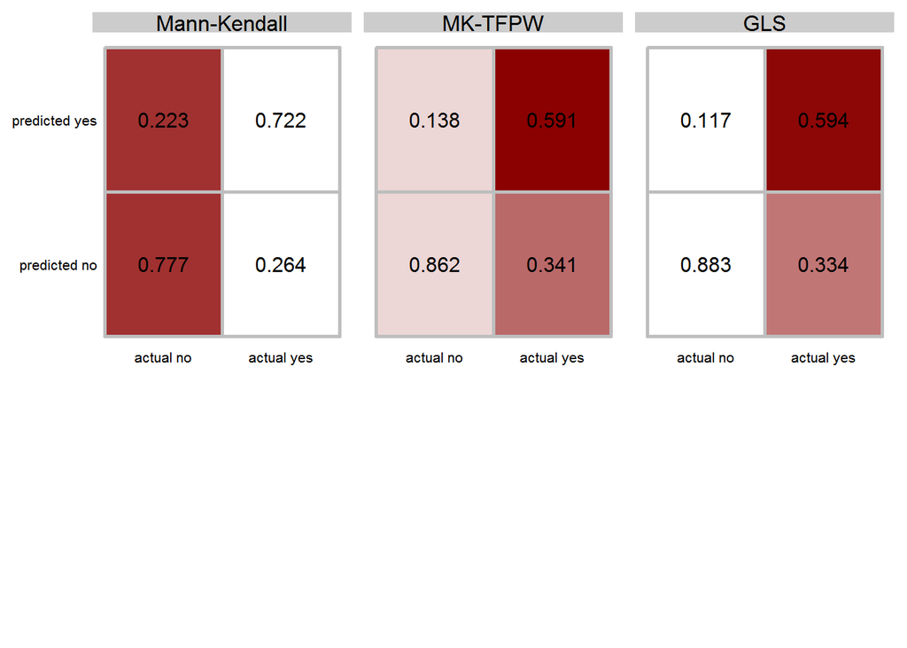

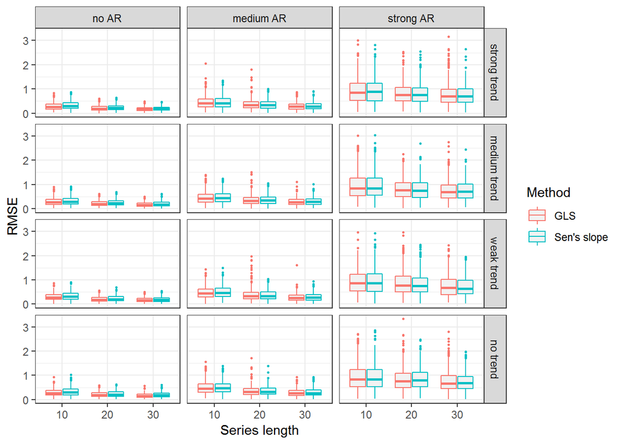